# Dive Deeper: ARIMA Workflow

Your Name

May 28, 2021

```r
library(tidyverse)
library(lubridate) # date manipulation
library(padr) # TS padding
library(zoo) # TS padding
library(fpp) # TS dataset
library(TSstudio) # TS interactive viz

library(forecast) # TS library
library(TTR) # SMA function
library(tseries) # adf.test

# supaya semua plot memiliki theme_minimal()
theme_set(theme_minimal())
```

# 1 Dive Deeper: ARIMA

Kita akan melakukan fitting model dan forecasting menggunakan metode ARIMA untuk data personal consumption expenditure per kuarternya di US dari tahun 1970 sampai 2010 (41 tahun).

## 1.1 Import Data

```r
# import data
usc <- fpp::usconsumption[, 'consumption']
head(usc, 12)
```

```
#>            Qtr1       Qtr2       Qtr3       Qtr4
#> 1970  0.6122769  0.4549298  0.8746730 -0.2725144
#> 1971  1.8921870  0.9133782  0.7928579  1.6499957
#> 1972  1.3272483  1.8899051  1.5327242  2.3170578
```

```r
class(usc)
```

```
#> [1] "ts"
```

Dikarenakan data sudah merupakan objek time series, maka kita tidak perlu mengubahnya

## 1.2 Exploratory Data

Lakukan visualisasi dengan fungsi `autoplot()`

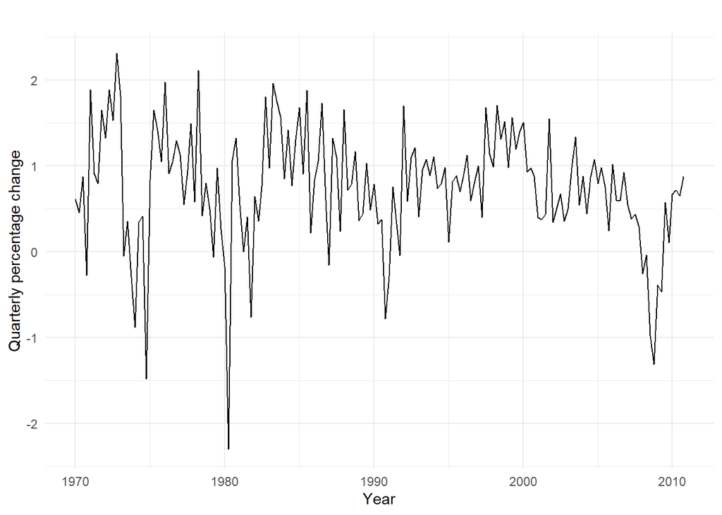

```r
usc %>%
  autoplot() +
  xlab("Year") +
  ylab("Quarterly percentage change")
```

**Insight:** Bagaimana trend dan seasonality dari US consumption?

- trend: sedikit fluktuatif
- seasonality: tidak ada pola berulang

> Apabila Anda ragu apakah sebuah data time series memiliki pola berulang atau tidak, Anda dapat menggunakan test statistic seperti WO test. NAMUN, menurut Rob Hyndman tes tersebut hanya sebagai referensi tambahan saja. Alangkah lebih baik tetap mengutamakan hasil visualisasi ataupun berdasarkan business knowledgenya.

Referensi: [Detecting seasonality](https://robjhyndman.com/hyndsight/detecting-seasonality/)

```r
# OPTIONAL: seasonality test
library(seastests)
summary(wo(usc))
```

```
#> Test used:  WO
#>
#> Test statistic:  0
#> P-value:  1 1 0.3824589
#>
#> The WO - test does not identify  seasonality
```

## 1.3 Cross Validation

Lakukan train-test splitting, gunakan 8 tahun terakhir sebagai data test, sisanya sebagai data train. Ingat:

- Panjang data `usc` adalah 41 tahun
- Frekuensi data adalah 4 (quarterly)

```r
# data test
usc_test <- tail(usc, 8*4)

# data train
usc_train <- head(usc, -8*4)
```

## 1.4 Fitting Model

### 1.4.1 Model Auto

Silahkan gunakan `auto.arima()` untuk mendapatkan baseline model ARIMA.

```r
usc_auto <- auto.arima(y = usc_train, seasonal = FALSE)
summary(usc_auto)
```

```
#> Series: usc_train
#> ARIMA(1,0,1) with non-zero mean
#>
#> Coefficients:
#>          ar1      ma1    mean
#>       0.7209  -0.4867  0.8225
#> s.e.  0.1202   0.1417  0.1041
#>
#> sigma^2 estimated as 0.4431:  log likelihood=-132.13
#> AIC=272.26   AICc=272.57   BIC=283.79
#>
#> Training set error measures:
#>                       ME      RMSE       MAE  MPE MAPE      MASE        ACF1
#> Training set 0.001810751 0.6580432 0.4911355 -Inf  Inf 0.6804473 -0.03652176
```

Dihasilkan model ARIMA(1,0,1)

### 1.4.2 Model Manual

Selanjutnya, lakukan tuning model dengan tentukan order p, d, q secara manual.

**Menentukan order d**

Cek stasioneritas data dengan `adf.test()`. Berikut hipotesisnya:

- $H_0$: Punya unit root (tidak stasioner)
- $H_1$: Tidak punya unit root (stasioner)

```r
usc_train %>%
  adf.test()
```

```
#>
#>  Augmented Dickey-Fuller Test
#>
#> data:  .
#> Dickey-Fuller = -3.9829, Lag order = 5, p-value = 0.01228
#> alternative hypothesis: stationary
```

Kesimpulan:

- Nilai p-value lebih kecil dari alpha (0.05)
- Maka dapat disimpulkan data sudah stasioner

Apabila belum, maka lakukan differencing hingga stasioner (no trend, no seasonality).

```r
# sudah stasioner, tidak perlu differencing
```

Kesimpulan: order d = 0

**Menentukan order p dan q**

Membuat plot ACF dan PACF

```r
# custom function untuk plot ACF dan PACF
library(patchwork)

plot_cf <- function(x, lag.max = NULL){
  p1 <- ggAcf(x, lag.max=lag.max) + labs(title = "Plot ACF and PACF")
  p2 <- ggPacf(x, lag.max=lag.max) + labs(title = NULL)
  p1 / p2
}
```

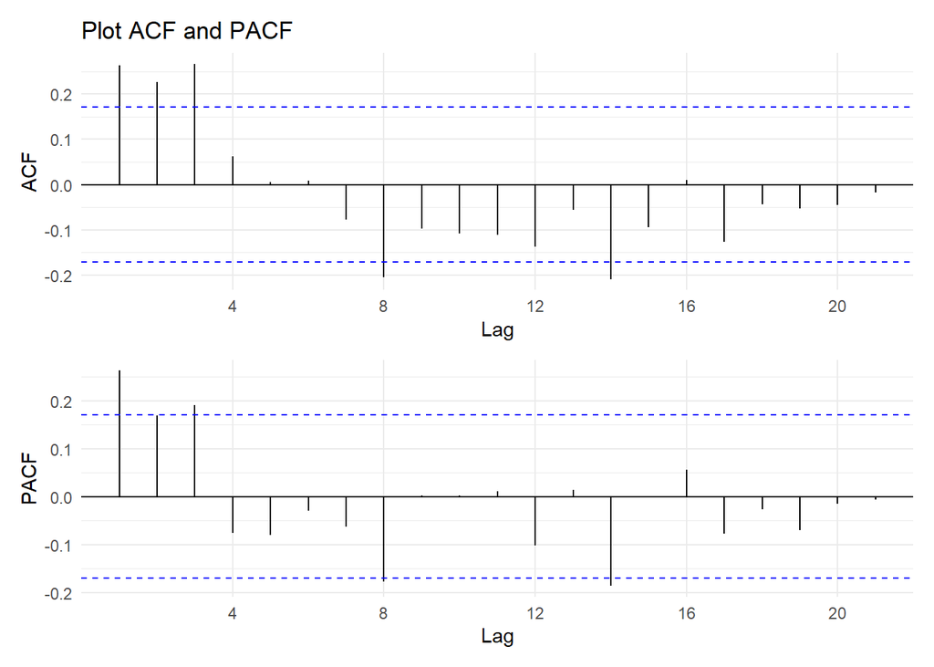

```r
plot_cf(usc_train)
```

Kemungkinan order p: 1,2,3 Kemungkinan order q: 1,2,3

Kombinasi model ARIMA(p,d,q):

- ARIMA(1,0,1)
- ARIMA(1,0,2)
- ARIMA(1,0,3)
- ARIMA(2,0,1)
- ARIMA(2,0,2)
- ARIMA(2,0,3)
- ARIMA(3,0,1)
- ARIMA(3,0,2)
- ARIMA(3,0,3)

Mari fitting kombinasi model tersebut dengan `Arima()`:

```r
# apabila kombinasi model dirasa terlalu banyak, untuk latihan kali ini cukup buat 3 kombinasi saja
usc_arima1 <- Arima(y = usc_train, order = c(3,0,1))
usc_arima2 <- Arima(y = usc_train, order = c(3,0,2))
usc_arima3 <- Arima(y = usc_train, order = c(3,0,3))
```

Bandingkan performa masing-masing model di data train dengan `compare_fitting()`

```r
# custom function untuk membandingkan performa di data train
compare_fitting <- function(x){
  lapply(x, function(x) summary(x)["Training set", ]) %>%
    lapply(., function(x) x %>% t() %>% as.data.frame) %>%
    bind_rows() %>%
    mutate(model = names(x)) %>%
    select(model, everything())
}
```

```r
model_list <- list(
  "ARIMA(1,0,1)" = usc_auto,
  "ARIMA(3,0,1)" = usc_arima1,
  "ARIMA(3,0,2)" = usc_arima2,
  "ARIMA(3,0,3)" = usc_arima3)

compare_fitting(model_list)
```

[output not shown]

| model | ME | RMSE | MAE | MPE | MAPE | MASE | ACF1 |
| --- | --- | --- | --- | --- | --- | --- | --- |
| ARIMA(1,0,1) | 0.0018107505 | 0.6580432 | 0.4911355 | -Inf | Inf | 0.6804473 | -0.036521765 |
| ARIMA(3,0,1) | 0.0015721301 | 0.6477724 | 0.4773937 | -Inf | Inf | 0.6614086 | 0.004805339 |
| ARIMA(3,0,2) | 0.0008333223 | 0.6450900 | 0.4759990 | -Inf | Inf | 0.6594762 | -0.006575842 |
| ARIMA(3,0,3) | 0.0009193058 | 0.6435095 | 0.4818710 | -Inf | Inf | 0.6676117 | -0.012464940 |

MAPE Inf karena terdapat data yang bernilai 0 pada `usc_train`. Maka dari itu, gunakanlah metric yang lain seperti RMSE/MAE

```r
usc_train == 0
```

```
#>       Qtr1  Qtr2  Qtr3  Qtr4
#> 1970 FALSE FALSE FALSE FALSE
#> 1971 FALSE FALSE FALSE FALSE
#> 1972 FALSE FALSE FALSE FALSE
#> 1973 FALSE FALSE FALSE FALSE
#> 1974 FALSE FALSE FALSE FALSE
#> 1975 FALSE FALSE FALSE FALSE
#> 1976 FALSE FALSE FALSE FALSE
#> 1977 FALSE FALSE FALSE FALSE
#> 1978 FALSE FALSE FALSE FALSE
#> 1979 FALSE FALSE FALSE FALSE
#> 1980 FALSE FALSE FALSE FALSE
#> 1981 FALSE  TRUE FALSE FALSE
#> 1982 FALSE FALSE FALSE FALSE
#> 1983 FALSE FALSE FALSE FALSE
```

[output cut: 19 more lines]

## 1.5 Forecasting

Gunakan `forecast()` untuk masing-masing model yang Anda buat sebelumnya:

```r
usc_auto_f <- forecast(usc_auto, h = 8*4)
usc_arima1_f <- forecast(usc_arima1, h = 8*4)
usc_arima2_f <- forecast(usc_arima2, h = 8*4)
usc_arima3_f <- forecast(usc_arima3, h = 8*4)
```

## 1.6 Model Evaluation

Bandingkan performa masing-masing model di data test dengan `compare_forecast()`

```r
# custom function untuk membandingkan performa di data test
compare_forecast <- function(x, test){
  lapply(x, function(x) forecast::accuracy(x, test)["Test set", ]) %>%
    lapply(., function(x) x %>% t() %>% as.data.frame) %>%
    bind_rows() %>%
    mutate(model = names(x)) %>%
    select(model, everything())
}
```

```r
forecast_list <- list(
  "ARIMA(1,0,1)" = usc_auto_f,
  "ARIMA(3,0,1)" = usc_arima1_f,
  "ARIMA(3,0,2)" = usc_arima2_f,
  "ARIMA(3,0,3)" = usc_arima3_f)

compare_forecast(forecast_list, usc_test)
```

| model | ME | RMSE | MAE | MPE | MAPE | MASE | ACF1 | Theil's U |
| --- | --- | --- | --- | --- | --- | --- | --- | --- |
| ARIMA(1,0,1) | -0.3553268 | 0.6925982 | 0.4696143 | 71.55813 | 174.9655 | 0.6506306 | 0.6877405 | 1.867870 |
| ARIMA(3,0,1) | -0.3541172 | 0.6941218 | 0.4715340 | 71.63530 | 175.1658 | 0.6532903 | 0.6845948 | 1.868066 |
| ARIMA(3,0,2) | -0.3616395 | 0.6936025 | 0.4667401 | 71.09371 | 175.1097 | 0.6466484 | 0.6853426 | 1.870693 |
| ARIMA(3,0,3) | -0.3624860 | 0.6957428 | 0.4731263 | 70.73816 | 176.0802 | 0.6554964 | 0.6848079 | 1.871034 |

Visualisasikan hasil forecasting model

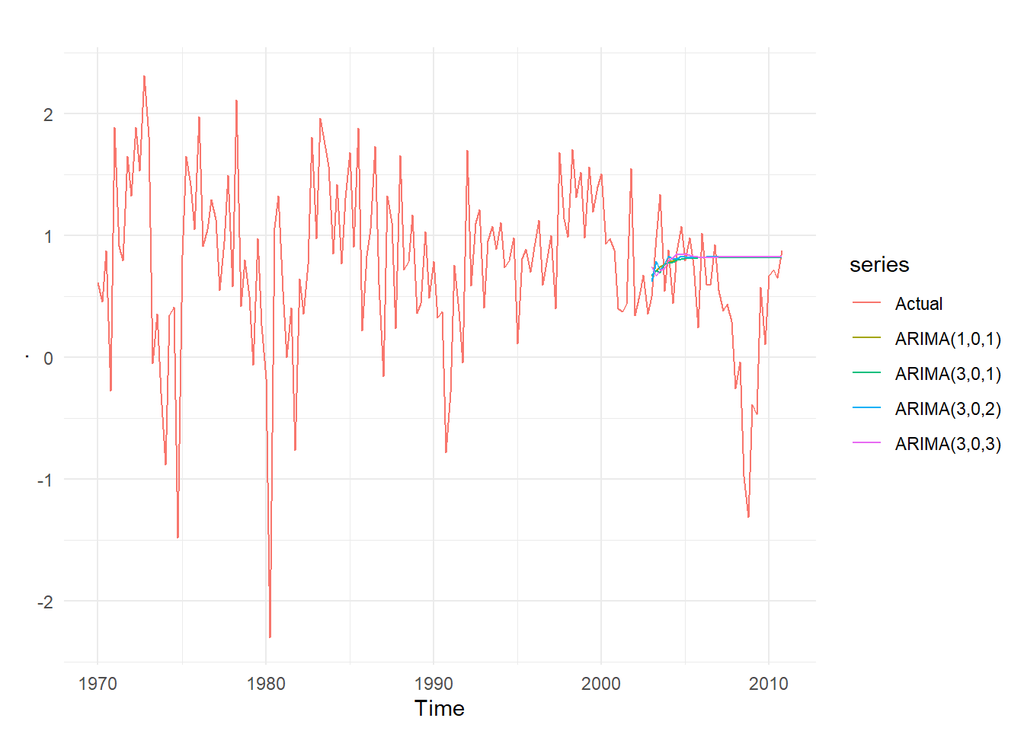

```r
usc %>%
  autoplot(series = "Actual") +
  autolayer(usc_auto_f$mean, series = "ARIMA(1,0,1)") +
  autolayer(usc_arima1_f$mean, series = "ARIMA(3,0,1)") +
  autolayer(usc_arima2_f$mean, series = "ARIMA(3,0,2)") +
  autolayer(usc_arima3_f$mean, series = "ARIMA(3,0,3)")
```

Kesimpulan:

- Model terbaik di data test adalah ARIMA(1,0,1) berdasarkan RMSE terkecil
- Training error = 0.6580432 (RMSE)
- Testing error = 0.6925982 (RMSE)
- Apakah underfit/best fit/overfit? underfit karena error masih tergolong besar sekali

Note: kita dapat membandingkan RMSE dengan standar deviasi (stdev) data asli, apabila RMSE mendekati nilai stdev maka performa model masih buruk.

```r
# standar deviasi data asli
sd(usc)
```

```
#> [1] 0.6936005
```